# Experiment Title

# Analysis

I ran a series of Mann-Kendall and Pettitt tests to find where the statistically significant breakpoints were in the monthly summary data. First, the Mann-Kendall test on the entire data set showed that there was a significant negative trend for all of the years of ozone data. Next, the pettitt test on the entire data set showed that there was a break point at the year 1995. Mann-Kendall tests on the data before and after the break point showed a significant negative trend between 1980 and 1995 and significant positive trend from 1995 to 2018. A second Pettitt test showed another break point in 2011. The Mann-Kendall tests showed there was not a significant trend from 1995 to 2011 and a significant positive trend from 2011 to 2018. A third Pettitt test showed one more break point at 2016. The Mann-Kendall tests showed there was a significant positive trend from 2011 to 2016, and no significant trend between 2016 and 2019. A final Pettitt test was run on the remaining section to ensure there were no more statistically significant break points in the data remaining.

```r
mk.test(O3_total_month_processed$MeanAQI)
```

```
##
##  Mann-Kendall trend test
##
## data:  O3_total_month_processed$MeanAQI
## z = -27.304, n = 3951, p-value < 2.2e-16
## alternative hypothesis: true S is not equal to 0
## sample estimates:
##             S          varS           tau
## -2.260713e+06  6.855566e+09 -2.897297e-01
```

```r
pettitt.test(O3_total_month_processed$MeanAQI) #change point at 1500
```

```
##
##  Pettitt's test for single change-point detection
##
## data:  O3_total_month_processed$MeanAQI
## U* = 2454000, p-value < 2.2e-16
## alternative hypothesis: two.sided
## sample estimates:
## probable change point at time K
##                            1500
```

```r
mk.test(O3_total_month_processed$MeanAQI[1:1499])
```

```
##
##  Mann-Kendall trend test
##
## data:  O3_total_month_processed$MeanAQI[1:1499]
## z = -5.1171, n = 1499, p-value = 3.102e-07
## alternative hypothesis: true S is not equal to 0
## sample estimates:
##             S          varS           tau
## -9.904400e+04  3.746245e+08 -8.822030e-02
```

```r
mk.test(O3_total_month_processed$MeanAQI[1500:3951])
```

```
##
##  Mann-Kendall trend test
##
## data:  O3_total_month_processed$MeanAQI[1500:3951]
## z = 7.2036, n = 2452, p-value = 5.863e-13
## alternative hypothesis: true S is not equal to 0
## sample estimates:
##            S         varS          tau
## 2.916390e+05 1.639020e+09 9.706037e-02
```

```r
pettitt.test(O3_total_month_processed$MeanAQI[1500:3951]) #change point at 1790 +1500
```

```
##
##  Pettitt's test for single change-point detection
##
## data:  O3_total_month_processed$MeanAQI[1500:3951]
## U* = 227390, p-value = 1.462e-09
## alternative hypothesis: two.sided
## sample estimates:
## probable change point at time K
##                            1790
```

```r
mk.test(O3_total_month_processed$MeanAQI[1500:3289])
```

```
##
##  Mann-Kendall trend test
##
## data:  O3_total_month_processed$MeanAQI[1500:3289]
## z = 1.8849, n = 1790, p-value = 0.05945
## alternative hypothesis: true S is not equal to 0
## sample estimates:
##            S         varS          tau
## 4.760300e+04 6.377932e+08 2.973262e-02
```

```r
mk.test(O3_total_month_processed$MeanAQI[3290:3951])
```

```
##
##  Mann-Kendall trend test
##
## data:  O3_total_month_processed$MeanAQI[3290:3951]
## z = 2.9277, n = 662, p-value = 0.003415
## alternative hypothesis: true S is not equal to 0
## sample estimates:
##            S         varS          tau
## 1.664200e+04 3.230810e+07 7.606989e-02
```

```r
pettitt.test(O3_total_month_processed$MeanAQI[3290:3951]) #change point at 3290+ 243
```

```
##
##  Pettitt's test for single change-point detection
##
## data:  O3_total_month_processed$MeanAQI[3290:3951]
## U* = 18004, p-value = 0.002478
## alternative hypothesis: two.sided
## sample estimates:
## probable change point at time K
##                             243
```

```r
mk.test(O3_total_month_processed$MeanAQI[3290:3775])
```

```
##
##  Mann-Kendall trend test
##
## data:  O3_total_month_processed$MeanAQI[3290:3775]
## z = 2.618, n = 486, p-value = 0.008846
## alternative hypothesis: true S is not equal to 0
## sample estimates:
##            S         varS          tau
## 9.365000e+03 1.279379e+07 7.946947e-02
```

```r
mk.test(O3_total_month_processed$MeanAQI[3776:3951])
```

```
##
##  Mann-Kendall trend test
##
## data:  O3_total_month_processed$MeanAQI[3776:3951]
## z = -0.83549, n = 176, p-value = 0.4034
## alternative hypothesis: true S is not equal to 0
## sample estimates:
##             S          varS           tau
## -6.540000e+02  6.108627e+05 -4.247305e-02
```

```r
pettitt.test(O3_total_month_processed$MeanAQI[3776:3951]) #change point not significant
```

```
##
##  Pettitt's test for single change-point detection
##
## data:  O3_total_month_processed$MeanAQI[3776:3951]
## U* = 1387, p-value = 0.2436
## alternative hypothesis: two.sided
## sample estimates:
## probable change point at time K
##                             114
```

```r
O3_alldata_processed$DAILY_AQI_VALUE <- as.numeric(O3_alldata_processed$DAILY_AQI_VALUE)
O3_alldata_processed_timeseries_season <- ts(O3_alldata_processed$DAILY_AQI_VALUE,
                                start = c(1980, 1) ,frequency = 4)

O3_alldata_season_smk <- smk.test(O3_alldata_processed_timeseries_season)
summary(O3_alldata_season_smk)
```

```
##
##  Seasonal Mann-Kendall trend test (Hirsch-Slack test)
##
## data: O3_alldata_processed_timeseries_season
## alternative hypothesis: two.sided
##
## Statistics for individual seasons
##
## H0
##                           S         varS    tau      z   Pr(>|z|)
## Season 1:   S = 0 -11299544 2.772015e+12 -0.027 -6.787 1.1467e-11 ***
## Season 2:   S = 0 -11753598 2.772032e+12 -0.028 -7.059 1.6715e-12 ***
## Season 3:   S = 0 -11894469 2.772026e+12 -0.028 -7.144 9.0600e-13 ***
## Season 4:   S = 0 -10999066 2.772012e+12 -0.026 -6.606 3.9405e-11 ***
## ---
## Signif. codes:  0 '***' 0.001 '**' 0.01 '*' 0.05 '.' 0.1 ' ' 1
```

```r
O3_alldata_processed_timeseries_month <- ts(O3_alldata_processed$DAILY_AQI_VALUE,
                                start = c(1980, 1) ,frequency = 12)

O3_alldata_month_smk <- smk.test(O3_alldata_processed_timeseries_month)
summary(O3_alldata_month_smk)
```

```
##
##  Seasonal Mann-Kendall trend test (Hirsch-Slack test)
##
## data: O3_alldata_processed_timeseries_month
## alternative hypothesis: two.sided
##
## Statistics for individual seasons
##
## H0
##                           S         varS    tau      z   Pr(>|z|)
## Season 1:   S = 0  -1431794 102687255634 -0.030 -4.468 7.8921e-06 ***
## Season 2:   S = 0  -1417358 102687481705 -0.030 -4.423 9.7323e-06 ***
## Season 3:   S = 0  -1518742 102688379095 -0.032 -4.739 2.1436e-06 ***
## Season 4:   S = 0  -1316975 102686618118 -0.028 -4.110 3.9601e-05 ***
## Season 5:   S = 0  -1012104 102688613953 -0.021 -3.158 0.00158652  **
## Season 6:   S = 0  -1201587 102688467008 -0.026 -3.750 0.00017706 ***
## Season 7:   S = 0  -1306967 102687768801 -0.028 -4.079 4.5319e-05 ***
## Season 8:   S = 0  -1150782 102689041525 -0.024 -3.591 0.00032925 ***
## Season 9:   S = 0  -1320892 102656313482 -0.028 -4.123 3.7457e-05 ***
## Season 10:   S = 0 -1298046 102658010792 -0.028 -4.051 5.0936e-05 ***
## Season 11:   S = 0 -1135191 102657128173 -0.024 -3.543 0.00039557 ***
## Season 12:   S = 0 -1197109 102655990485 -0.025 -3.736 0.00018675 ***
## ---
## Signif. codes:  0 '***' 0.001 '**' 0.01 '*' 0.05 '.' 0.1 ' ' 1
```

Finally, since the data was not normally distributed, I ran a Kruskal-Wallis test to determine if there was a significant difference in Ozone concentration between each site. The results of the test showed that there is a significant difference between the monthly averaged AQI values for each site between 1980 and 2018.

```r
O3_total_month_processed$Site.Name <- as.factor(O3_total_month_processed$Site.Name)
kruskal.test(O3_total_month_processed$MeanAQI, O3_total_month_processed$Site.Name)
```

```
##
##  Kruskal-Wallis rank sum test
##
## data:  O3_total_month_processed$MeanAQI and O3_total_month_processed$Site.Name
## Kruskal-Wallis chi-squared = 102.21, df = 8, p-value < 2.2e-16
```

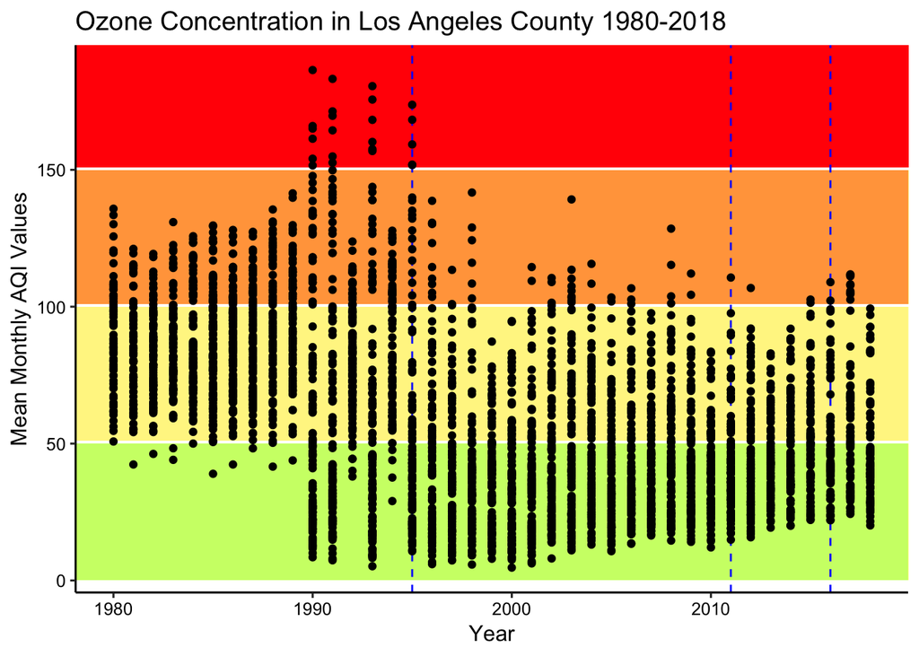

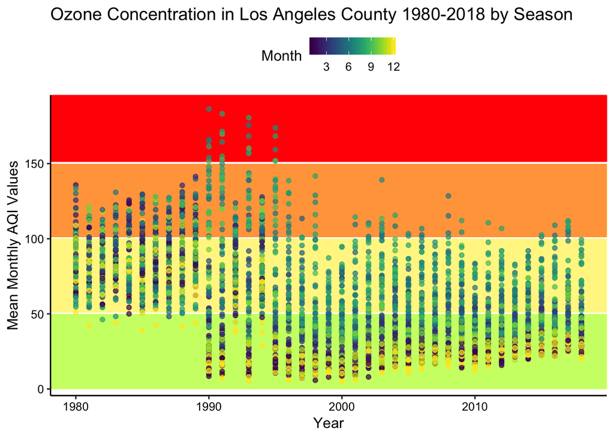

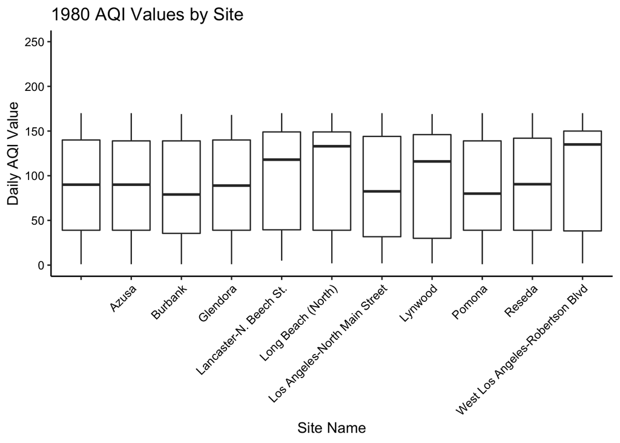

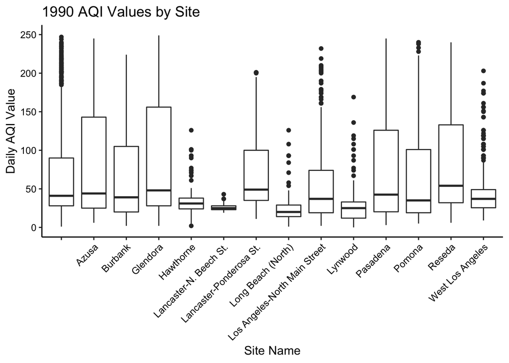

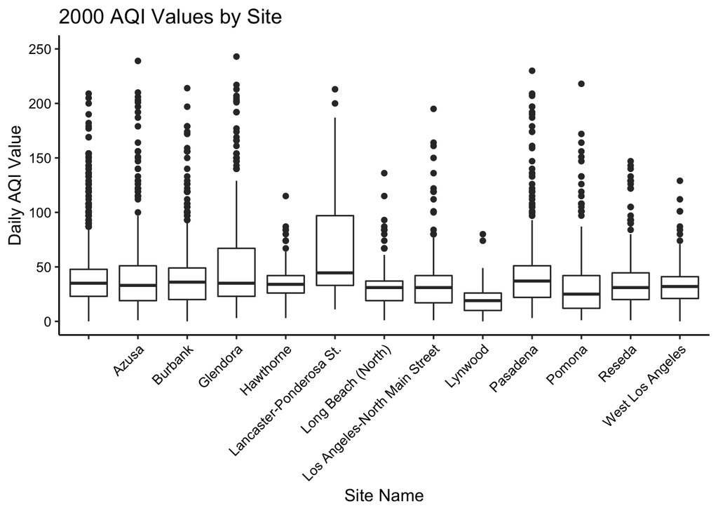

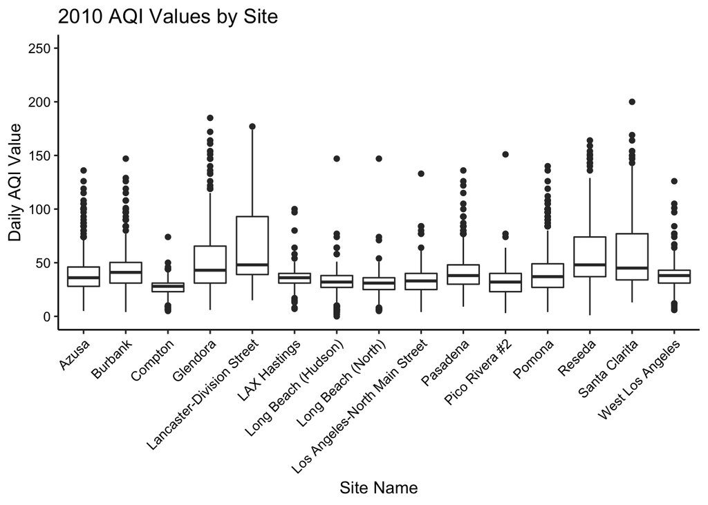

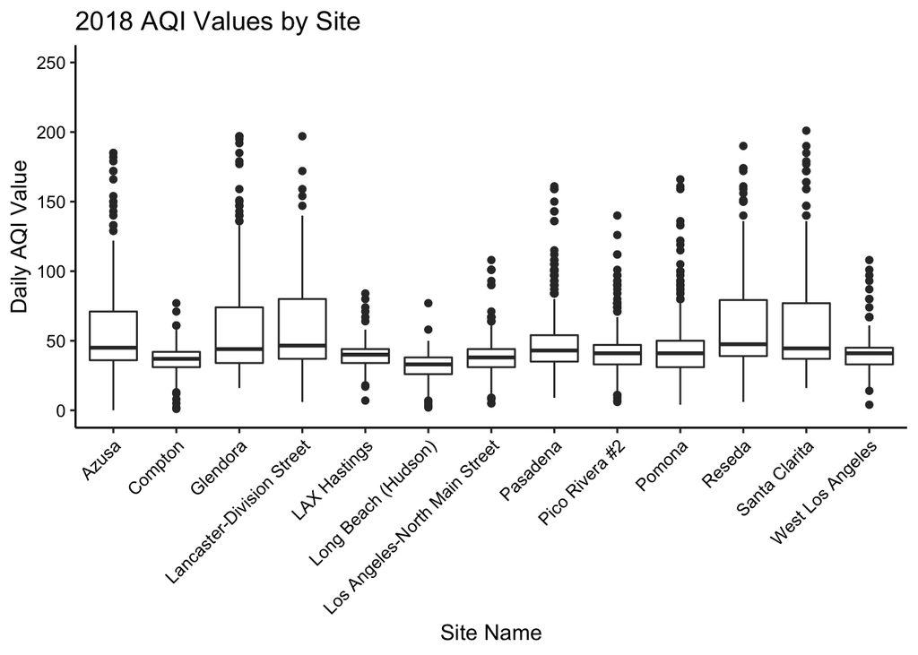

# Sources

Haagen-Smit, A. J. (1952). Chemistry and physiology of Los Angeles smog. Industrial & Engineering Chemistry, 44(6), 1342-1346.

Sillman, S. (2003). Overview: Tropospheric ozone, smog and ozone-NOx-VOC sensitivity. Treatise on Geochemistry.